# Taller 1 - Simulación

2022-03-16

### **EJERCICIO 1°**

Al comparar los caracteres morfométricos de una especie de langostinos de gran importancia económica en Argentina se observaron diferencias de tamaño entre macho y hembra. En la siguiente tabla se presentan los datos (Largo total mm) de las morfometrías de machos y hembras obtenidos en diferentes recolectas (Ruiz & Mendia, 2008).

| HEMBRAS |  |  |  |  |  |  |
| --- | --- | --- | --- | --- | --- | --- |
| 183.2 | 182.5 | 166.8 | 184.1 | 190.0 | 196.3 | 183.0 |
| 176.5 | 180.4 | 185.8 | 179.0 | 184.3 | 189.3 | 188.3 |
| 202.2 | 203.1 | 210.8 |  |  |  |  |

| MACHOS |  |  |  |  |  |  |
| --- | --- | --- | --- | --- | --- | --- |
| 140.9 | 173.9 | 118.9 | 121.7 | 177.4 | 140.0 | 173.8 |
| 109.2 | 153.4 | 175.0 | 150.7 | 138.7 | 169.8 | 203.3 |
| 137.7 | 126.7 | 150.0 |  |  |  |  |

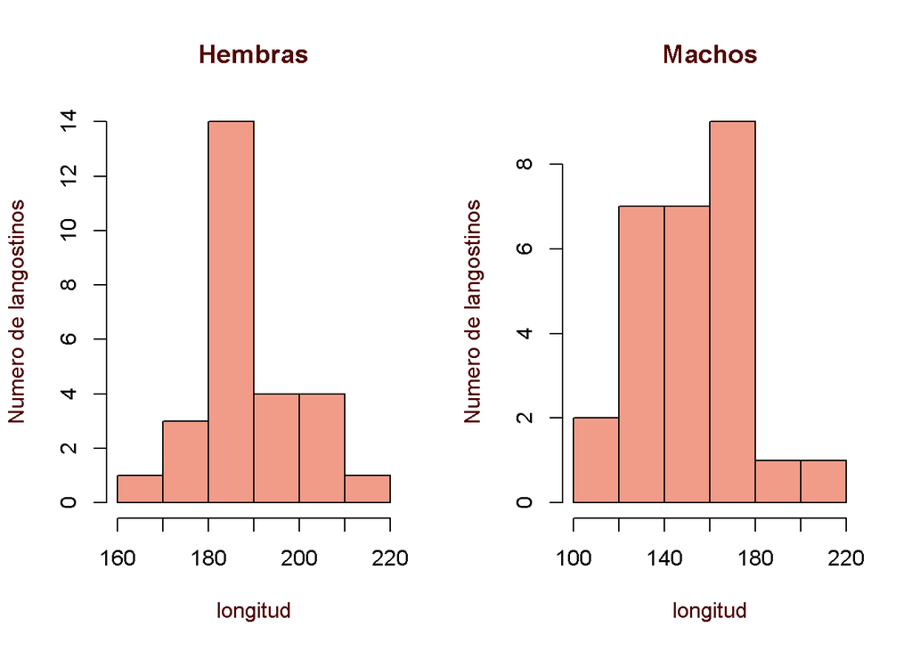

El problema nos presenta una distribucion normal tanto para hembras, como machos debido a las caracteristicas de sus datos ya que son continuos y Mediante el coeficiente de simetria para los datos de ambos sexos nos arrojan la sigueinte información de su comportamiento.

```
## [1] "variable de asimetria 0.205650428677704"
```

```
## [1] "El coeficiente de curtosis:  2.94575826066672"
```

```
## [1] "variable de asimetria 0.0447538385858831"
```

```
## [1] "El coeficiente de curtosis:  2.42572491394268"
```

**B.** Hallar el promedio y la desviación estándar para cada sexo. ¿Qué puede concluir?

```
## [1] "Promedio HEMBRAS:  189.066666666667"
```

```
## [1] "Desviación estandat HEMBRAS:  9.83115143111622"
```

[output not shown]

[output not shown]

###### **Estos datos estadisticos nos indican que el tamaño promedio de los langostinos machos es de 154.4667 y su desviación estandar de 23.0642 nos muestra la dispersion de los datos con respecto a su media, en este caso, nos da a conocer que los datos se encuentran un poco dispersos entre sí.**

**C.** Halle un intervalo para la media del Largo total por sexo con un nivel de confianza del 97%. Provea la inter-pretación respectiva.

```
## [1] "Limite inferior para el intervalo de confianza de las HEMBRAS:  184.960842705843"
```

```
## [1] "Limite superior para el intervalo de confianza de las HEMBRAS:  193.172490627491"
```

```
## [1] "Limite inferior para el intervalo de confianza de las MACHOS:  144.834093072312"
```

```
## [1] "Limite superior para el intervalo de confianza de las MACHOS:  164.099240261022"
```

###### **El intervalo de confianza para las MACHOS VA DESDE 144.8341 A 164.0992 dandonos a entender que cualquier longitud fuera de estos margenes es poco probable que suceda ya que hay un 97% de confianza que el dato este entre los valores**

**D.** Construya un Boxplot por sexo e interprételo.

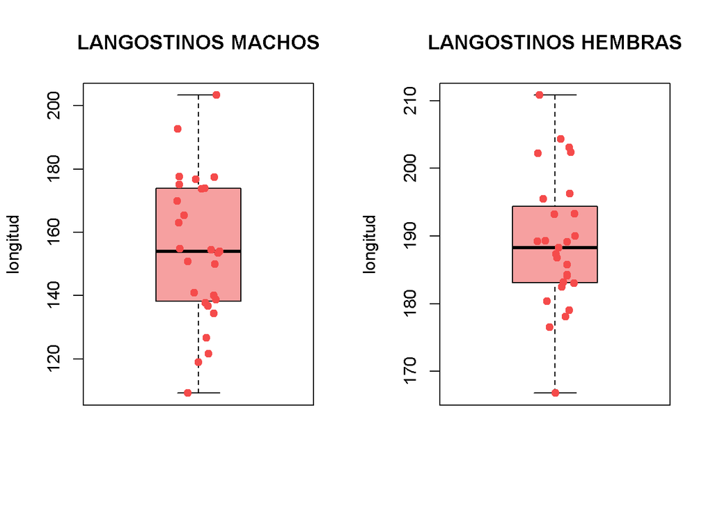

**E.** Compruebe a normalidad de los datos.

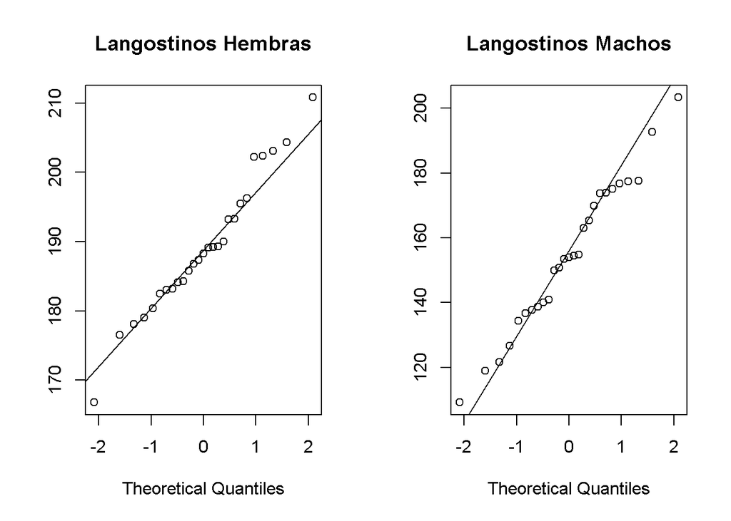

Como vemos graficamente en las graficas tanto los langostinos macho y los langostinos hembra, los datos forman una linea aproximadamente recta a lo largo de la linea. La distibucion normal parece ajustarse con los datos de los langostinos, por ende podemos decir que las graficas parecen obedecer a un grafico de distribucion normal.

### **EJERCICIO 2°**

En un restaurante de la ciudad se sabe que la probabilidad de que se reciba un billete de $50.000 falso es de 0.015. Si se sabe que en una semana se reciben pagos con 900 billetes de $50.000, halle la probabilidad de que:

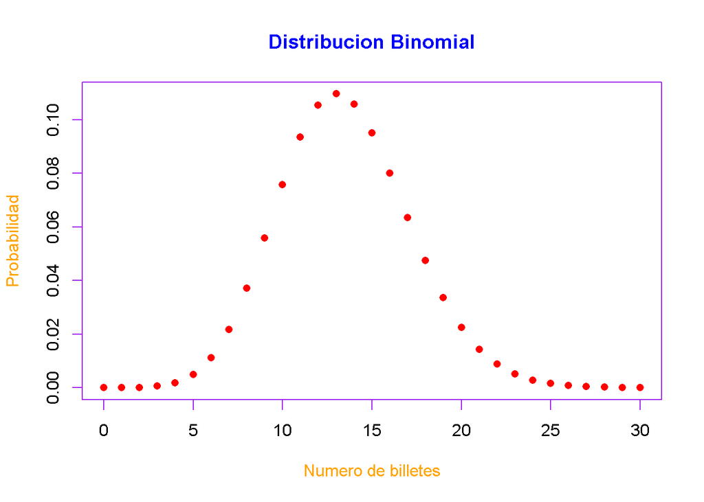

**A.** A lo sumo 25 billetes sean falsos.

```
## [1] "P(X1<=25)"
```

```
## [1] "La probabilidad de que a lo sumo 25 billetes sean falsos es de  0.998519866673255"
```

**B.** La cantidad de billetes falsos esté entre 20 y 30.

```
## [1] "P(X>=20) y P(X<=30)"
```

[output not shown]

**C.** Más de 10 sean falsos.

```
## [1] "P(X>10)"
```

```
## [1] "La probabilidad de que hayan más de 10 billetes sean falsos es de  0.790781595552497"
```

### **EJERCICIO 3°**

Según un estudio del Departamento Nacional de Estadística -DANE-, la vida media para el quinquenio de 2010 a 2015 de los habitantes de Colombia es 76 años, con una varianza de 25. Se pretende hacer un estudio con el objetivo de extrapolar los resultados anteriores a una pequeña ciudad de 100.000 habitantes, considerando que el tiempo de sobrevida es normal.

[figure not shown]

```
## [1] 0.00712072
```

```
## [1] 0.5609667
```

**A.** ¿Cuántos de los habitantes de la pequeña ciudad superarán previsiblemente los 92 años?

[output not shown]

**B.** ¿Cuántos vivirán menos de 55 años o más de 75 años?

[output not shown]